# pymongo_analysis

```python
import pymongo
from pprint import pprint
from twitter_api import *

import numpy as np
import matplotlib.pyplot as plt
import pandas as pd
import seaborn as sns

seed = 42
np.random.seed(seed)
```

```python
client = pymongo.MongoClient('localhost', 27017)
client.list_database_names()
```

```
['admin', 'config', 'local', 'twitter_stream']
```

```python
db = client['twitter_stream']
db.list_collection_names()
```

```
['tweets', 'users']
```

```python
db.tweets.find_one()
```

```
{'_id': ObjectId('60616488155014bfff6d797a'),
 'created_at': 'Sun Mar 28 18:50:38 +0000 2021',
 'id': 1376245361245847559,
 'id_str': '1376245361245847559',
 'full_text': '@AymanGelberto هو فيه مدرب اجنبى جه درب مصر ب ٥٠ الف دولار؟',
 'truncated': False,
 'display_text_range': [15, 59],
 'entities': {'hashtags': [],
  'symbols': [],
  'user_mentions': [{'screen_name': 'AymanGelberto',
    'name': 'Ayman Gelbo',
    'id': 242006178,
    'id_str': '242006178',
    'indices': [0, 14]}],
  'urls': []},
 'source': '<a href="http://twitter.com/download/iphone" rel="nofollow">Twitter for iPhone</a>',
 'in_reply_to_status_id': 1376220085912735755,
 'in_reply_to_status_id_str': '1376220085912735755',
 'in_reply_to_user_id': 242006178,
 'in_reply_to_user_id_str': '242006178',
 'in_reply_to_screen_name': 'AymanGelberto',
 'user': {'id': 196267549,
  'id_str': '196267549',
  'name': 'مَحمود',
  'screen_name': 'MSha3bo',
  'location': '🌍',
  'description': 'تاخدوا كام وتبطلوا كلام 🚚',
  'url': None,
  'entities': {'description': {'urls': []}},
  'protected': False,
  'followers_count': 437,
  'friends_count': 148,
  'listed_count': 0,
  'created_at': 'Tue Sep 28 18:35:43 +0000 2010',
  'favourites_count': 9770,
  'utc_offset': None,
  'time_zone': None,
  'geo_enabled': True,
  'verified': False,
  'statuses_count': 9968,
```

[output cut: 18 more lines]

```
  'default_profile_image': False,
  'following': False,
  'follow_request_sent': False,
  'notifications': False,
  'translator_type': 'none'},
 'geo': None,
 'coordinates': None,
 'place': None,
 'contributors': None,
 'is_quote_status': False,
 'retweet_count': 0,
 'favorite_count': 0,
 'favorited': False,
 'retweeted': False,
 'lang': 'ar'}
```

```python
# querying tweets for certain user
count = 0
limit = 10
for tweet in db.tweets.find({'user.screen_name': 'MSha3bo'}):
    if count > limit:
        break
    pprint(tweet['full_text'])
    count += 1
```

```
'@AymanGelberto هو فيه مدرب اجنبى جه درب مصر ب ٥٠ الف دولار؟'
'@tpf_Amelie @_3b3ziz_ @joinClubhouse شوف ايفون 5 عندكو فى البيت'
('@_3b3ziz_ @joinClubhouse @tpf_Amelie والله لسه بقول لرجبولى زيزو لازم '
 'يشاركنا 😂😂😂')
'اللى مش معاه ايفون قدامه بكرة ينزل يشترى'
("I'm discussing “محلات الفرايد تشيكن ما بين الحقيقة والسراب” with Ahmed "
 'Ragab. Today, Mar 28 at 6:00 PM GMT 2 on @joinclubhouse. Join us! '
 'https://t.co/k5r1LpEf08\n'
 '\n'
 'دعوة لمشاركتى الحديث مع صديقى الخبير البهنساوى @tpf_amelie')
'@Mahmoud_1ashraf @Ahmedkolkeila الصحة خلاص'
'https://t.co/ufdUNUfQvu https://t.co/93GBuTVdbG'
'عذر اقبح من ذنب https://t.co/1N4WvxnEfe'
'اللى صورها معرفش يحط الكاميرا بين السلك؟ https://t.co/NhEsbTotOd'
'اه والله https://t.co/xNKohsAQeo'
'هو وليد سليمان فين؟'
```

```python
# querying one user
db.users.find_one()
```

```
{'_id': ObjectId('60616488155014bfff6d79f2'),
 'id': 196267549,
 'id_str': '196267549',
 'name': 'مَحمود',
 'screen_name': 'MSha3bo',
 'location': '🌍',
 'description': 'تاخدوا كام وتبطلوا كلام 🚚',
 'url': None,
 'entities': {'description': {'urls': []}},
 'protected': False,
 'followers_count': 437,
 'friends_count': 148,
 'listed_count': 0,
 'created_at': 'Tue Sep 28 18:35:43 +0000 2010',
 'favourites_count': 9770,
 'utc_offset': None,
 'time_zone': None,
 'geo_enabled': True,
 'verified': False,
 'statuses_count': 9968,
 'lang': None,
 'status': {'created_at': 'Mon Mar 29 00:32:25 +0000 2021',
  'id': 1376331375968665601,
  'id_str': '1376331375968665601',
  'text': 'RT @Amr21DS: ما تاخذ دقيقة من وقتك : \n\n- سُبحان الله\n- الحمدلله \n- لا إله إلا الله \n- اللهُ أكبر \n- سُبحان الله و بحمدهِ\n- سُبحان الله العظ…',
  'truncated': False,
  'entities': {'hashtags': [],
   'symbols': [],
   'user_mentions': [{'screen_name': 'Amr21DS',
     'name': 'Amr',
     'id': 1623857720,
     'id_str': '1623857720',
     'indices': [3, 11]}],
   'urls': []},
  'source': '<a href="http://twitter.com/download/iphone" rel="nofollow">Twitter for iPhone</a>',
  'in_reply_to_status_id': None,
  'in_reply_to_status_id_str': None,
  'in_reply_to_user_id': None,
  'in_reply_to_user_id_str': None,
  'in_reply_to_screen_name': None,
```

[output cut: 45 more lines]

```
 'profile_image_url': 'http://pbs.twimg.com/profile_images/1360536034786897925/EdGWLHg-_normal.jpg',
 'profile_image_url_https': 'https://pbs.twimg.com/profile_images/1360536034786897925/EdGWLHg-_normal.jpg',
 'profile_banner_url': 'https://pbs.twimg.com/profile_banners/196267549/1595613935',
 'profile_link_color': '1F98C7',
 'profile_sidebar_border_color': 'FFFFFF',
 'profile_sidebar_fill_color': 'DAECF4',
 'profile_text_color': '663B12',
 'profile_use_background_image': True,
 'has_extended_profile': True,
 'default_profile': False,
 'default_profile_image': False,
 'following': False,
 'follow_request_sent': False,
 'notifications': False,
 'translator_type': 'none'}
```

```python
# querying all screen_names
screen_names = []
for user in db.users.find():
    screen_names.append(user['screen_name'])

screen_names = set(screen_names)
print('Total number of users:', len(screen_names))
```

```
Total number of users: 5389
```

```python
# converting users collection into pandas dataframe
import pandas as pd

users_df = pd.DataFrame(list(db.users.find()))
users_df.head()
```

|  | _id | id | id_str | name | screen_name | location | description | url | entities | protected | ... | default_profile | default_profile_image | following | follow_request_sent | notifications | translator_type | live_following | muting | blocking | blocked_by |
| --- | --- | --- | --- | --- | --- | --- | --- | --- | --- | --- | --- | --- | --- | --- | --- | --- | --- | --- | --- | --- | --- |
| 0 | 60616488155014bfff6d79f2 | 196267549 | 196267549 | مَحمود | MSha3bo | 🌍 | تاخدوا كام وتبطلوا كلام 🚚 | None | {'description': {'urls': []}} | False | ... | False | False | False | False | False | none | NaN | NaN | NaN | NaN |
| 1 | 60616496155014bfff6d79f8 | 797176867853836288 | 797176867853836288 | Fatmakhalid1966 | Fatmakhalid1961 |  |  | None | {'description': {'urls': []}} | False | ... | True | True | False | False | False | none | False | False | False | False |
| 2 | 6061649c155014bfff6d7a84 | 1618738735 | 1618738735 | 𝙊𝙠𝙖𝙨𝙝𝙖🕷 | NumbSlump | Egypt | 🇪🇬 | None | {'description': {'urls': []}} | False | ... | False | False | False | False | False | none | False | False | False | False |
| 3 | 606164a7155014bfff6d7b46 | 1275854348564803584 | 1275854348564803584 | asmaa | asmmaakm |  |  | None | {'description': {'urls': []}} | False | ... | True | False | False | False | False | none | False | False | False | False |
| 4 | 606164aa155014bfff6d7bb0 | 1400988632 | 1400988632 | 𝖇𝖚𝖇𝖇𝖑𝖊𝖘 | maiisadiq |  | اول شي، بنسوار. | https://t.co/uvzkHovzTb | {'url': {'urls': [{'url': 'https://t.co/uvzkHo... | False | ... | False | False | False | False | False | none | False | False | False | False |

5 rows × 48 columns

## Analyzing users' friends and followers distributions

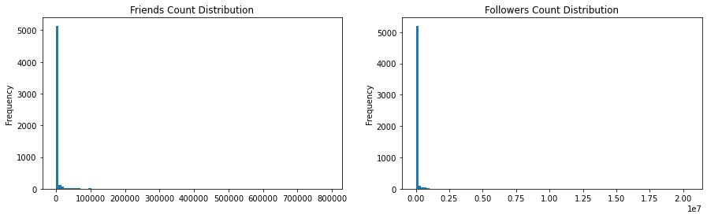

```python
fig, axes = plt.subplots(1, 2, figsize=(15, 4))

users_df.friends_count.plot(kind='hist', ax=axes[0], bins=100, title='Friends Count Distribution')
users_df.followers_count.plot(kind='hist', ax=axes[1], bins=100, title='Followers Count Distribution');
```

The two histograms have outliers (of course), so let's boxplot them to check them out.

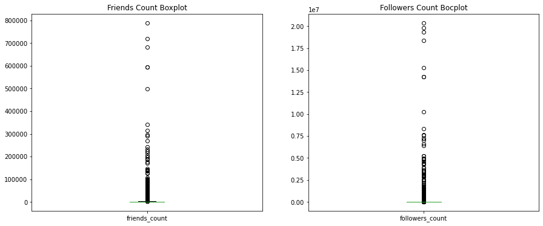

```python
fig, axes = plt.subplots(1, 2, figsize=(15, 6))

users_df.friends_count.plot(kind='box', ax=axes[0], title='Friends Count Boxplot')
users_df.followers_count.plot(kind='box', ax=axes[1], title='Followers Count Bocplot');
```

```python
users_df.loc[:, ['friends_count', 'followers_count']].describe()
```

|  | friends_count | followers_count |
| --- | --- | --- |
| count | 5458.000000 | 5.458000e+03 |
| mean | 3989.544339 | 8.611468e+04 |
| std | 27053.326770 | 7.634366e+05 |
| min | 0.000000 | 0.000000e+00 |
| 25% | 140.000000 | 1.080000e+02 |
| 50% | 430.000000 | 6.580000e+02 |
| 75% | 1332.750000 | 5.382500e+03 |
| max | 790290.000000 | 2.038353e+07 |

The outliers won't enable any real insight to be taken from the distribution of users, so let's take a look at a clean version of the data.

```python
thresh = 0.95
outliers_mask = (users_df.friends_count < users_df.friends_count.quantile(thresh)) &\
                (users_df.followers_count < users_df.followers_count.quantile(thresh))
```

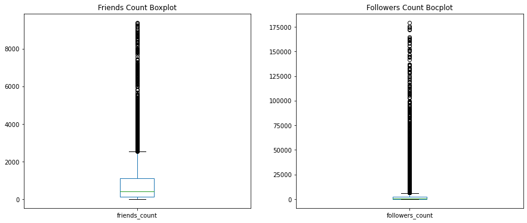

```python
fig, axes = plt.subplots(1, 2, figsize=(15, 6))

users_df[outliers_mask].friends_count.plot(kind='box', ax=axes[0], title='Friends Count Boxplot')
users_df[outliers_mask].followers_count.plot(kind='box', ax=axes[1], title='Followers Count Bocplot');
```

```python
users_df.loc[outliers_mask, ['friends_count', 'followers_count']].describe()
```

|  | friends_count | followers_count |
| --- | --- | --- |
| count | 4953.000000 | 4953.000000 |
| mean | 1014.975974 | 6740.896225 |
| std | 1527.490005 | 20649.815357 |
| min | 0.000000 | 0.000000 |
| 25% | 143.000000 | 86.000000 |
| 50% | 400.000000 | 489.000000 |
| 75% | 1107.000000 | 2597.000000 |
| max | 9411.000000 | 179530.000000 |

Since the two distributions are heavily skewed, we shall user the median as a representative of the average number of friends and followers, and it is observed after the data is cleaned that the median friends and followers count is 400 and 489, while the median count before cleaning was 430 and 658.

```python
print('Number of outliers:', users_df.shape[0] - users_df[outliers_mask].shape[0])
print('Outliers friends and followers summary:')
users_df.loc[~outliers_mask, ['friends_count', 'followers_count']].describe()
```

```
Number of outliers: 505
Outliers friends and followers summary:
```

|  | friends_count | followers_count |
| --- | --- | --- |
| count | 505.000000 | 5.050000e+02 |
| mean | 33163.875248 | 8.646064e+05 |
| std | 83436.575149 | 2.374284e+06 |
| min | 0.000000 | 8.801000e+03 |
| 25% | 84.000000 | 3.686600e+04 |
| 50% | 10329.000000 | 2.052180e+05 |
| 75% | 27612.000000 | 5.394210e+05 |
| max | 790290.000000 | 2.038353e+07 |

The condition that I chose for the setting the outliers mask depended that both friends and followers counts weren't outliers, therefore the minimum followers count in the outliers is less than the maximum followers count in the clean version of the data.

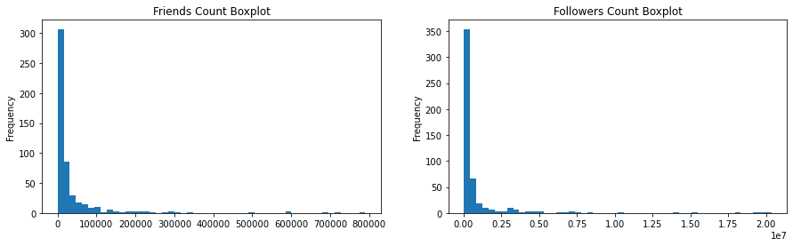

```python
fig, axes = plt.subplots(1, 2, figsize=(15, 4))

users_df[~outliers_mask].friends_count.plot(kind='hist', ax=axes[0], bins=50, title='Friends Count Boxplot')
users_df[~outliers_mask].followers_count.plot(kind='hist', ax=axes[1], bins=50, title='Followers Count Boxplot');
```

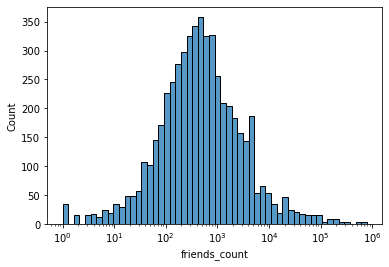

```python
# new addition
sns.histplot(data=users_df.query('friends_count > 0'), x='friends_count', log_scale=True);
```

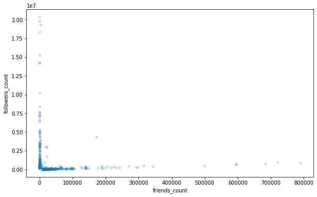

```python
users_df[~outliers_mask].plot(kind='scatter',
                              x='friends_count',
                              y='followers_count',
                              alpha=0.2,
                              figsize=(10, 6));
```

These outliers are distributed on the two axes, so there are basically people who have really low followers count and huge friends count or the opposite. Let's take a look at the cleaned version.

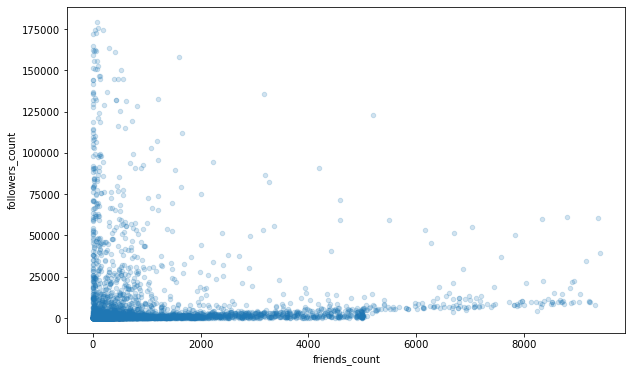

```python
users_df[outliers_mask].plot(kind='scatter',
                             x='friends_count',
                             y='followers_count',
                             figsize=(10, 6),
                             alpha=0.2);
```

There is some sort of linear relationship going on below 25000 followers. I guess that these are users that get followers by following other users in return of these users following them back. That's why these have an apparent linear relationship between friends and followers count.

On the other hand we can see the other distribution of users who don't show a linear relationship between these two features, and these may be the users who have amassed a following based on their activity, and not relying on quid pro quo agreement with other users to follow them and expect a follow back.

## Clustering users based on friends and followers count

```python
# Kmeans clustering
from sklearn.cluster import KMeans

k = 5
kmeans = KMeans(n_clusters=k)

y_pred = kmeans.fit_predict(users_df.loc[outliers_mask, ['friends_count', 'followers_count']])
```

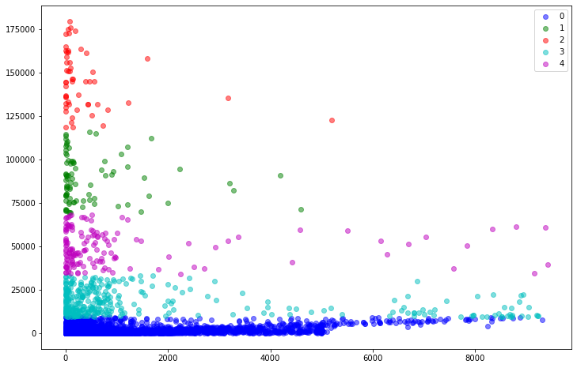

```python
color_mapping = {cluster: color for cluster, color in zip(set(y_pred), 'bgrcmy')}
plt.figure(figsize=(12, 8))

for cluster, color in color_mapping.items():
    plt.scatter(x=users_df[outliers_mask][y_pred == cluster]['friends_count'],
                y=users_df[outliers_mask][y_pred == cluster]['followers_count'],
                c=color,
                alpha=0.5,
                label=cluster);

plt.legend();
```

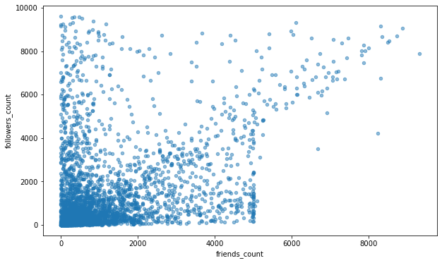

```python
users_df[outliers_mask][y_pred == 0].plot(kind='scatter',
                             x='friends_count',
                             y='followers_count',
                             figsize=(10, 6),
                             alpha=0.5);
```

In the first cluster we can visualize a linear relationship between friends and followers count in users with less than 10000 followers, where that represents a cutoff and the relationship then ceases to exist in further clusters.

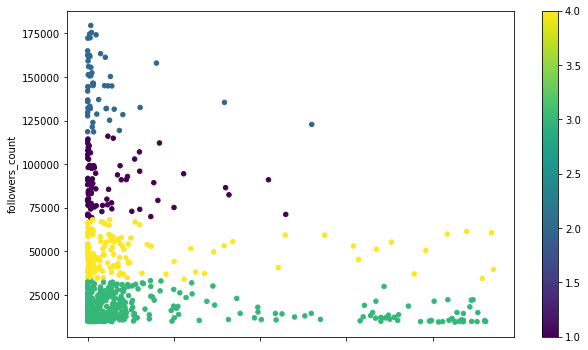

```python
users_df[outliers_mask][y_pred != 0].plot(kind='scatter',
                             x='friends_count',
                             y='followers_count',
                             figsize=(10, 6),
                             c=y_pred[y_pred != 0],
                             cmap='viridis');
```

Passing on to the rest of the clusters we can see that what distinguishes each cluster from another is that width of the friends count distribution gets narrower and narrower, with less and and less outliers, indicating that the majority of users who have a large following base didn't get there by the quid pro quo way that some of the users in cluster 0 did.

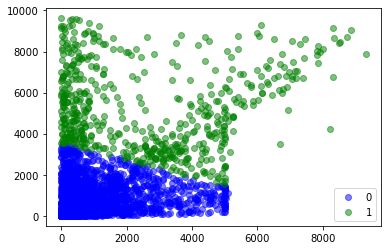

```python
k = 2
kmeans = KMeans(n_clusters=k)

y_pred_2 = kmeans.fit_predict(users_df[outliers_mask][y_pred == 0][['friends_count', 'followers_count']])

for label, color in zip(set(y_pred_2), 'bgrcmy'):
    plt.scatter(x=users_df[outliers_mask][y_pred == 0][y_pred_2 == label]['friends_count'],
                y=users_df[outliers_mask][y_pred == 0][y_pred_2 == label]['followers_count'],
                c=color,
                alpha=0.5,
                label=label);

plt.legend();
```

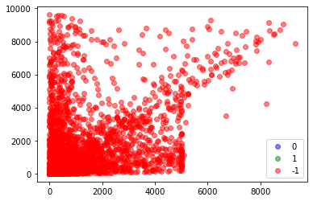

```python
from sklearn.cluster import DBSCAN

dbscan = DBSCAN(eps=0.2, min_samples=5)

dbscan.fit(users_df[outliers_mask][y_pred == 0][['friends_count', 'followers_count']])

for label, color in zip(set(dbscan.labels_), 'bgrcmy'):
    plt.scatter(x=users_df[outliers_mask][y_pred == 0][dbscan.labels_ == label]['friends_count'],
                y=users_df[outliers_mask][y_pred == 0][dbscan.labels_ == label]['followers_count'],
                c=color,
                alpha=0.5,
                label=label);

plt.legend();
```

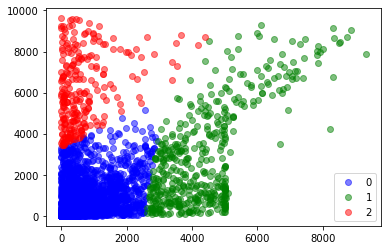

```python
from sklearn.mixture import GaussianMixture

n = 3
gm = GaussianMixture(n_components=n, n_init=10, covariance_type='tied')
gm.fit(users_df[outliers_mask][y_pred == 0][['friends_count', 'followers_count']])

y_pred_3 = gm.predict(users_df[outliers_mask][y_pred == 0][['friends_count', 'followers_count']])

for label, color in zip(set(y_pred_3), 'bgrcmy'):
    plt.scatter(x=users_df[outliers_mask][y_pred == 0][y_pred_3 == label]['friends_count'],
                y=users_df[outliers_mask][y_pred == 0][y_pred_3 == label]['followers_count'],
                c=color,
                alpha=0.5,
                label=label);

plt.legend();
```

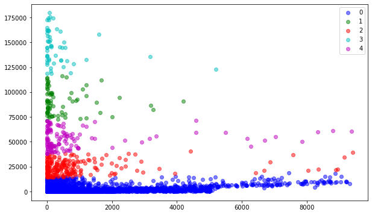

```python
n = 5
gm = GaussianMixture(n_components=n, n_init=10, covariance_type='tied')
gm.fit(users_df[outliers_mask][['friends_count', 'followers_count']])

y_pred_4 = gm.predict(users_df[outliers_mask][['friends_count', 'followers_count']])

plt.figure(figsize=(10, 6))

for label, color in zip(set(y_pred_4), 'bgrcmy'):
    plt.scatter(x=users_df[outliers_mask][y_pred_4 == label]['friends_count'],
                y=users_df[outliers_mask][y_pred_4 == label]['followers_count'],
                c=color,
                alpha=0.5,
                label=label);

plt.legend();
```

I think that gaussian mixture model nailed the clustering better than kmeans.

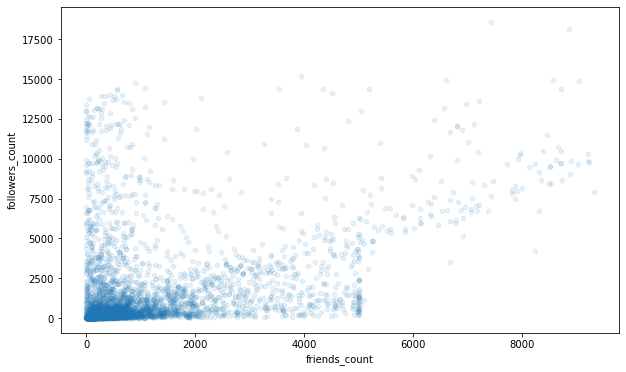

```python
users_df[outliers_mask][y_pred_4 == 0].plot(kind='scatter',
                             x='friends_count',
                             y='followers_count',
                             figsize=(10, 6),
                             alpha=0.1);
```

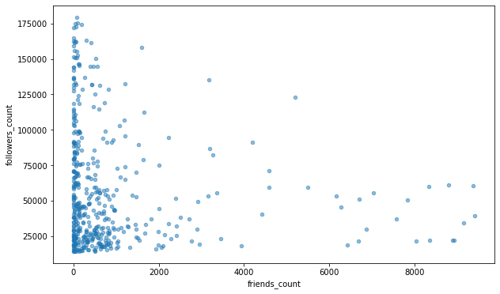

```python
users_df[outliers_mask][y_pred_4 != 0].plot(kind='scatter',
                             x='friends_count',
                             y='followers_count',
                             figsize=(10, 6),
                             alpha=0.5);
```

I still believe that this cluster can be further split into two cluster, and I could do that manually to further look into users who I think used the follow and follow back scheme of gathering followers.

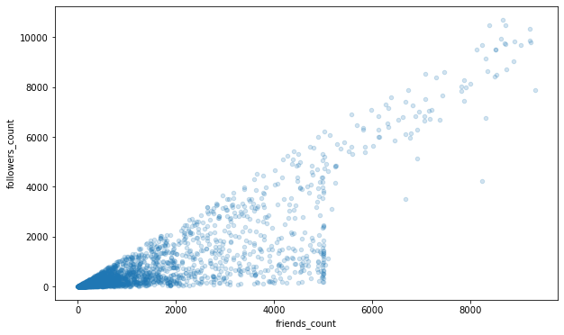

```python
cluster_0 = users_df[outliers_mask][y_pred_4 == 0]
thresh = 0.8
cluster_0_mask = (cluster_0['friends_count'] / (cluster_0['followers_count'] + 0.0001)) > thresh
users_df[outliers_mask][y_pred_4 == 0][cluster_0_mask].plot(kind='scatter',
                             x='friends_count',
                             y='followers_count',
                             figsize=(10, 6),
                             alpha=0.2);
```

Since the threshold is a hyperparamter in this expirement of analyzing users who might only have followers because they followed them in the first place, I'll analyze the whole cluster with no threshold, and with two thresholds to have a broader look into the data.

## Analyze time present for cluster 0

```python
import pytz
import datetime
from dateutil.relativedelta import relativedelta

utc=pytz.UTC

now = utc.localize(datetime.datetime.now())

users_df['delta'] = pd.to_datetime(users_df.created_at).apply(lambda x: relativedelta(now, x))
users_df['years'] = pd.to_datetime(users_df.created_at).apply(lambda x: relativedelta(now, x).years)
users_df['months'] = users_df.delta.apply(lambda x: x.years * 12 + x.months)
users_df['days'] = users_df.delta.apply(lambda x: x.years * 365 + x.days)
```

```python
def split_cluster_0(thresh):
    cluster_0_mask = (cluster_0['friends_count'] / (cluster_0['followers_count'] + 0.0001)) > thresh
    return cluster_0[cluster_0_mask], cluster_0[~cluster_0_mask]
```

```python
cluster_0 = users_df[outliers_mask][y_pred_4 == 0]
cluster_0_1, _ = split_cluster_0(0.4)
cluster_0_2, _ = split_cluster_0(0.8)
```

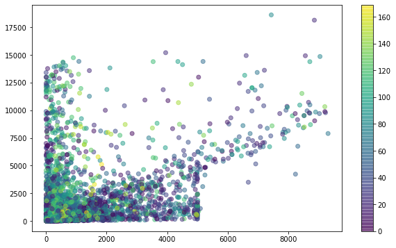

```python
# cluster_0.plot(kind='scatter',
#              x='friends_count',
#              y='followers_count',
#              figsize=(10, 6),
#              alpha=0.1,
#              s=cluster_0.months);

plt.figure(figsize=(10, 6))

plt.scatter(x=cluster_0['friends_count'],
            y=cluster_0['followers_count'],
            c=cluster_0['months'],
            alpha=0.5);
#             cmap='viridis_r');
plt.colorbar();
```

The months since account creation helped in further illuminating the differences between users in this cluster, and it shows the two clusters withing cluster 0, where some of the users have large number of followers and friends, and have not joined twitter since too long.

I guess that this could further be illuminated if we added statuses count into the plot.

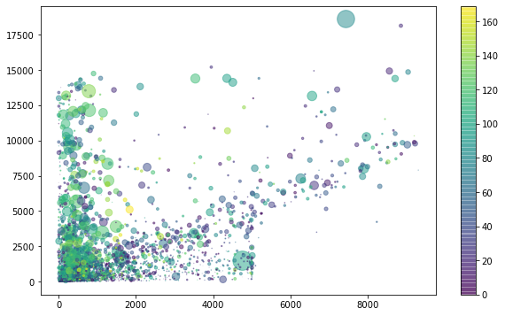

```python
plt.figure(figsize=(10, 6))

plt.scatter(x=cluster_0['friends_count'],
            y=cluster_0['followers_count'],
            c=cluster_0['months'],
            s=cluster_0['statuses_count']/1000,
            alpha=0.5)
#             cmap='viridis_r');
plt.colorbar();
```

This addition just made it really interesting, as it could be easily seen that the users that have low friends count and high followers count have high statuses count and have been on twitter for longer than the other category of the users, which have gained followers by follow back schemes and haven't been on twitter for so long.

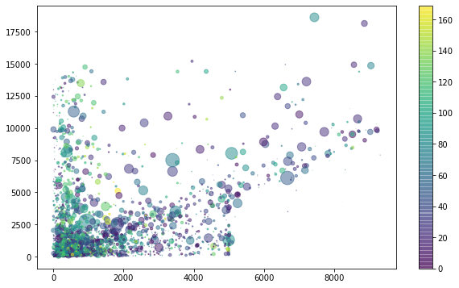

```python
plt.figure(figsize=(10, 6))

plt.scatter(x=cluster_0['friends_count'],
            y=cluster_0['followers_count'],
            c=cluster_0['months'],
            s=cluster_0['favourites_count']/1000,
            alpha=0.5)
#             cmap='viridis_r');
plt.colorbar();
```

From that perspective we can also see that the two categories of users differ in their favorties count. Users that have been long on twitter and have high followers and low friends count tend to have lower favourties count than users who haven't been on twitter for long and used follo back schemes to gain followers.

Now it would be interesting to test clustering users based on all of the features that we have visualized so far.

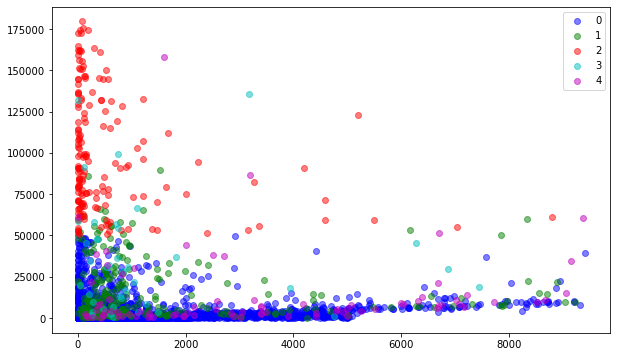

```python
k = 5
kmeans = KMeans(n_clusters=k)
cols = ['friends_count', 'followers_count', 'statuses_count', 'favourites_count', 'months']

y_pred = kmeans.fit_predict(users_df.loc[outliers_mask, cols])

color_mapping = {cluster: color for cluster, color in zip(set(y_pred), 'bgrcmy')}
plt.figure(figsize=(10, 6))

for cluster, color in color_mapping.items():
    plt.scatter(x=users_df[outliers_mask][y_pred == cluster]['friends_count'],
                y=users_df[outliers_mask][y_pred == cluster]['followers_count'],
                c=color,
                alpha=0.5,
                label=cluster);

plt.legend();
```

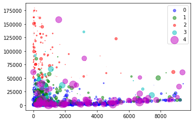

```python
for label, color in zip(set(y_pred), 'bgrcmy'):
    plt.scatter(x=users_df[outliers_mask][y_pred == label]['friends_count'],
                y=users_df[outliers_mask][y_pred == label]['followers_count'],
                c=color,
                s=users_df[outliers_mask][y_pred == label]['favourites_count']/1000,
                alpha=0.5,
                label=label);

plt.legend();
```

The results don't look good at all, since the algorithm isn't able to cluster user groups on any dimension.

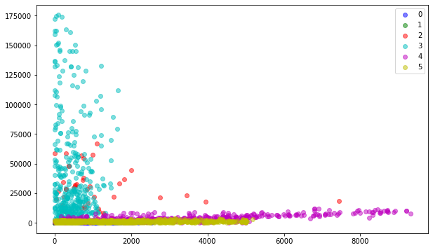

```python
n = 10
gm = GaussianMixture(n_components=n, n_init=10, random_state=44)
gm.fit(users_df[outliers_mask][cols])

y_pred_4 = gm.predict(users_df.loc[outliers_mask, cols])

plt.figure(figsize=(10, 6))

for label, color in zip(set(y_pred_4), 'bgrcmy'):
    plt.scatter(x=users_df[outliers_mask][y_pred_4 == label]['friends_count'],
                y=users_df[outliers_mask][y_pred_4 == label]['followers_count'],
                c=color,
                alpha=0.5,
                label=label);

plt.legend();
```

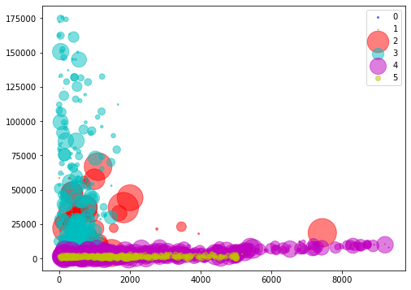

```python
plt.figure(figsize=(8, 6))
for label, color in zip(set(y_pred_4), 'bgrcmy'):
    plt.scatter(x=users_df[outliers_mask][y_pred_4 == label]['friends_count'],
                y=users_df[outliers_mask][y_pred_4 == label]['followers_count'],
                c=color,
                s=users_df[outliers_mask][y_pred_4 == label]['favourites_count']/100,
                alpha=0.5,
                label=label);

plt.legend();
```

The results are exceptional and by analyzing these groups, we might be able to extract new insights based on the users data.

```python
gm_0 = users_df[outliers_mask][y_pred_4 == 0]
gm_1 = users_df[outliers_mask][y_pred_4 == 1]
gm_2 = users_df[outliers_mask][y_pred_4 == 2]
gm_3 = users_df[outliers_mask][y_pred_4 == 3]
gm_4 = users_df[outliers_mask][y_pred_4 == 4]
gm_5 = users_df[outliers_mask][y_pred_4 == 5]
```

```python
def scatter_cluster(tmp, scale=1):
    plt.figure(figsize=(10, 6))
    plt.scatter(x=tmp['friends_count'],
                y=tmp['followers_count'],
                s=tmp['statuses_count']/scale,
                c=tmp['months'])
    plt.colorbar()
```

|  | friends_count | followers_count | statuses_count | favourites_count | months |
| --- | --- | --- | --- | --- | --- |
| count | 794.000000 | 794.000000 | 794.000000 | 794.000000 | 794.000000 |
| mean | 532.736776 | 137.717884 | 100.687657 | 169.570529 | 42.144836 |
| std | 527.263915 | 134.860905 | 90.667460 | 187.355165 | 37.999276 |
| min | 0.000000 | 0.000000 | 1.000000 | 0.000000 | 0.000000 |
| 25% | 154.000000 | 36.000000 | 30.250000 | 22.000000 | 10.000000 |
| 50% | 356.000000 | 97.000000 | 76.000000 | 105.500000 | 32.500000 |
| 75% | 731.750000 | 198.750000 | 145.750000 | 254.250000 | 65.000000 |
| max | 2763.000000 | 657.000000 | 426.000000 | 859.000000 | 149.000000 |

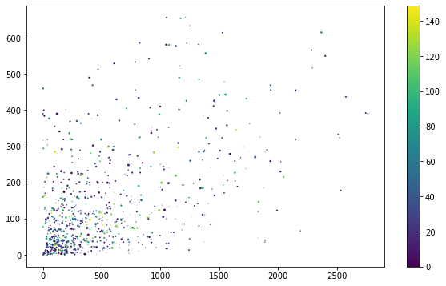

```python
scatter_cluster(gm_0, 100)
gm_0[cols].describe()
```

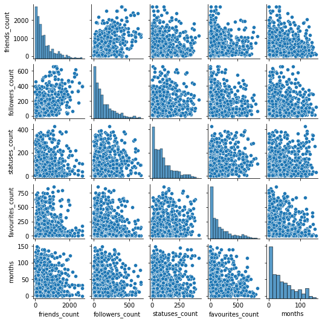

```python
sns.pairplot(gm_0[cols], height=1.5);
```

|  | friends_count | followers_count | statuses_count | favourites_count | months |
| --- | --- | --- | --- | --- | --- |
| count | 681.000000 | 681.000000 | 681.000000 | 681.000000 | 681.000000 |
| mean | 125.873715 | 19.171806 | 9.615272 | 18.518355 | 38.559471 |
| std | 107.412763 | 19.355608 | 10.058008 | 24.242222 | 35.378496 |
| min | 0.000000 | 0.000000 | 1.000000 | 0.000000 | 0.000000 |
| 25% | 46.000000 | 4.000000 | 2.000000 | 2.000000 | 6.000000 |
| 50% | 95.000000 | 13.000000 | 5.000000 | 8.000000 | 32.000000 |
| 75% | 167.000000 | 28.000000 | 14.000000 | 26.000000 | 60.000000 |
| max | 531.000000 | 89.000000 | 49.000000 | 117.000000 | 141.000000 |

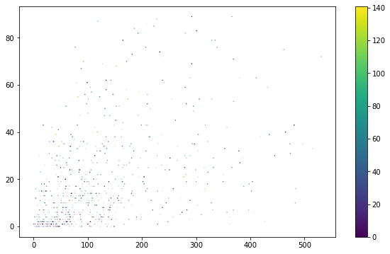

```python
scatter_cluster(gm_1, 100)
gm_1[cols].describe()
```